# H24064022_hw10

林承穎

2019/5/14

## 1. Introduction to R

### 1-1基本運算子

| 運算子 | 說明 |
| --- | --- |
| + | 加法 |
| - | 減法 |
| * | 乘法 |
| / | 除法 |
| ^ | 次方 |
| %% | 餘數 |
| %/% | 除法整數部分 |

#### *Example 1.1*

```r
3^4
```

```
## [1] 81
```

```r
31%%6
```

```
## [1] 1
```

```r
46%/%7
```

```
## [1] 6
```

### 1-2變數

> 我們可以建立變數，將數值或各種資料儲存起來

#### *Example 1.2*

```r
interest <- 1.0025^30
```

其中 `<-` 亦可用 `=` 取代，不過由於這邊我們是賦予變數一個數值，使用前者像箭頭的運算子較能符合這個意義

```r
interest
```

```
## [1] 1.077783
```

必須再輸入一次變數，才能將他呼叫出來，看看它的值

### 1-3向量

#### 數值向量

在 R 中最簡單的結構就是數值向量，可直接進行運算，利用 `c()` 可將物件收集成向量

```r
x<-c(0,7,8)
x
```

```
## [1] 0 7 8
```

#### *Example 1.3*

```r
y <- x-5
y
```

```
## [1] -5  2  3
```

```r
x*3
```

```
## [1]  0 21 24
```

`:`可用來創造一個遞增、遞減序列(sequence)

```r
numbers5to20 <- 5:20
numbers5to20
```

```
##  [1]  5  6  7  8  9 10 11 12 13 14 15 16 17 18 19 20
```

```r
numbers10to2 <- 10:2
numbers10to2
```

```
## [1] 10  9  8  7  6  5  4  3  2
```

利用 `[]` 來指定元素的索引（index），**索引以 1 為起始**，例如`numbers5to20`向量的第 3 個元素就是

```r
numbers5to20[3]
```

```
## [1] 7
```

亦可同時指定一個以上的索引

```r
numbers5to20[3:7]
```

```
## [1]  7  8  9 10 11
```

```r
numbers5to20[c(3,5,7,9)]
```

```
## [1]  7  9 11 13
```

透過 `[]` 也可以直接更改向量中的特定元素

```r
numbers5to20[3] <- 777
numbers5to20
```

```
##  [1]   5   6 777   8   9  10  11  12  13  14  15  16  17  18  19  20
```

#### 字元向量

由字串組成的向量，向量內的元素屬性必須相同

```r
colors <- c("red", "yellow", "blue")
more.colors <- c(colors, "green", "magenta", "cyan") # this appended some new elements to colors
more.colors
```

```
## [1] "red"     "yellow"  "blue"    "green"   "magenta" "cyan"
```

```r
z <- c("red", "green", 1)  # an attempt to mix data types in a vector
z # 1 has been converted to the character "1"
```

```
## [1] "red"   "green" "1"
```

### 1-4呼叫函數

> R有許多內建函數，我們僅需要在函數後的小括弧內放入參數執行，即可得到輸出結果

#### 數值向量函數

- `abs()` : 絕對值
- `sqrt()` : 開平方根
- `ceiling()` : 無條件進位
- `floor()` : 無條件捨去
- `round()` : 四捨五入
- `log()` : 以`e`為底取對數

#### 敘述統計函數

- `mean()` : 回傳向量的**平均**
- `sd()` : 回傳向量**標準差**
- `median()` : 回傳向量中的**中位數**
- `range()` : 回傳向量中**最大和最小值**
- `sum()` : 將向量的數值**加總**
- `max()` : 回傳向量中**最大值**
- `min()` : 回傳向量中**最小值**

#### 序列函數

除了在上一部分提到的利用`c()`及`:`產生序列，亦可利用 `seq()` 和 `rep()`來進行更多變化

#### *Example 1.4*

```r
seq(1, 20)
```

```
##  [1]  1  2  3  4  5  6  7  8  9 10 11 12 13 14 15 16 17 18 19 20
```

```r
seq(from = 1, to = 20)
```

```
##  [1]  1  2  3  4  5  6  7  8  9 10 11 12 13 14 15 16 17 18 19 20
```

```r
1:20
```

```
##  [1]  1  2  3  4  5  6  7  8  9 10 11 12 13 14 15 16 17 18 19 20
```

我們可以看到以上三種寫法的輸出結果是完全一樣的。若在括號內加入 `by` 這個參數，則可以調整序列的步長，沒加入`by`的話，預設值為`1`

```r
seq1 <- seq(-5, 5, by = 0.2)
seq1
```

```
##  [1] -5.0 -4.8 -4.6 -4.4 -4.2 -4.0 -3.8 -3.6 -3.4 -3.2 -3.0 -2.8 -2.6 -2.4
## [15] -2.2 -2.0 -1.8 -1.6 -1.4 -1.2 -1.0 -0.8 -0.6 -0.4 -0.2  0.0  0.2  0.4
## [29]  0.6  0.8  1.0  1.2  1.4  1.6  1.8  2.0  2.2  2.4  2.6  2.8  3.0  3.2
## [43]  3.4  3.6  3.8  4.0  4.2  4.4  4.6  4.8  5.0
```

還有一個相關的函數是 `rep()`，它可以用來重複一個物件

#### *Example 1.5*

```r
rep(3, 12)       # repeat the value 3, 12 times
```

```
##  [1] 3 3 3 3 3 3 3 3 3 3 3 3
```

```r
rep(seq(2, 20, by=2), 2)    # repeat the pattern 2 4 ... 20, twice
```

```
##  [1]  2  4  6  8 10 12 14 16 18 20  2  4  6  8 10 12 14 16 18 20
```

```r
rep(c(1, 4), c(3, 2))  # repeat 1, 3 times and  4, twice
```

```
## [1] 1 1 1 4 4
```

```r
rep(c(1, 4), each=3)   # repeat each value 3 times
```

```
## [1] 1 1 1 4 4 4
```

### 1-5 Data frames

> 類似矩陣，但每一行有自己的變數名稱，並且可以是不同的屬性。是R中常見的資料儲存格式，我們可以使用 `data.frame` 函數來建立

```r
colors <- c("red", "yellow", "blue")
numbers <- c(1, 2, 3)
colors.and.numbers <- data.frame(colors, numbers, more.numbers=c(4, 5, 6))
colors.and.numbers
```

```
##   colors numbers more.numbers
## 1    red       1            4
## 2 yellow       2            5
## 3   blue       3            6
```

可使用 `dimnames` 一次存取所有列與行的名稱。

```r
dimnames(colors.and.numbers)
```

```
## [[1]]
## [1] "1" "2" "3"
##
## [[2]]
## [1] "colors"       "numbers"      "more.numbers"
```

## 2. Programming with R

### 2-1 if else判斷式

> `if` 判斷式是一種**條件判斷**語法，他可以判斷一個輸入的邏輯值，如果輸入的值為 TRUE，則執行對應的程式碼，反之該值若為 FALSE，則不執行

將欲判斷的條件放在小括號內、欲執行的指令以大括號包起來

#### *Example 2.1*

```r
x <- 3
if (x > 2){
  y <- 2 * x
}else{           #else一定要和前一句的 } 寫在同一行
  y <- 3 * x
}
y
```

```
## [1] 6
```

#### *Example 2.2*

```r
x <- 5
if (x > 3){
  y <- 2 * x
}else if(x > 2){
  y <- 5 * x
}else{
  y <- 3 * x
}
y
```

```
## [1] 10
```

`if()`條件的判斷是有先後順序的，若if的敘述判斷為真，就算else if也為真，也只有第一個為真的條件會被執行

### 2-2 while迴圈

> while 迴圈是簡單的迴圈控制結構，會先檢查指定的條件，在條件為 TRUE 的情況下才會執行迴圈的內容

#### *Example 2.3*

```r
x <- 0
while (x != 5) {
  print(x)
  x <- x + 1
}
```

```
## [1] 0
## [1] 1
## [1] 2
## [1] 3
## [1] 4
```

### 2-3 for迴圈

> for 迴圈主要是用在程式執行前就已經給定執行範圍，他會在範圍內依序並且重複執行迴圈的內容

#### *Example 2.4*

```r
for ( x in 0:4 ) {
  print(x)
}
```

```
## [1] 0
## [1] 1
## [1] 2
## [1] 3
## [1] 4
```

若想終止迴圈則可使用 `break`

```r
for ( x in 0:8 ) {
  if(x==3) break
  print(x)
}
```

```
## [1] 0
## [1] 1
## [1] 2
```

## 3. Statistical graphics

### 3-1 Basic plots

> R內建了許多基礎繪圖函數，我們只需要選擇想要的圖表類型並輸入資料即可

### Bar charts

資料類型必須為**類別資料**，這裡以內建資料集 `VADeaths` 作為範例

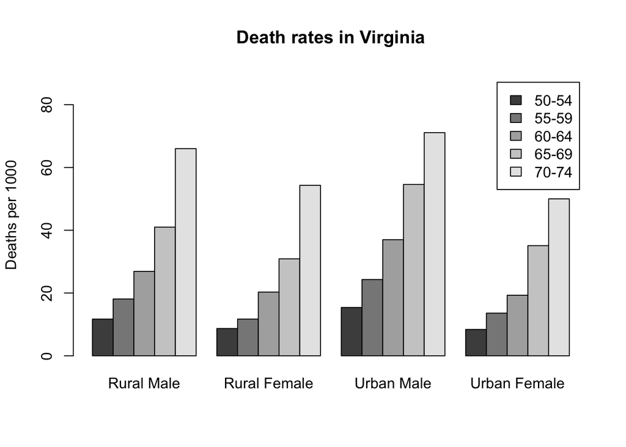

```r
barplot(VADeaths, beside=TRUE, legend=TRUE, ylim=c(0, 90),
         ylab="Deaths per 1000",
         main="Death rates in Virginia")
```

```r
# beside=TRUE argument causes the values in each column to be plotted side-by-side
# legend=TRUE causes the legend in the top right to be added
# ylim=c(0, 90) argument modifies the verti- cal scale of the graph to make room for the legend
# main=argument sets the main title for the plot
```

### Pie charts

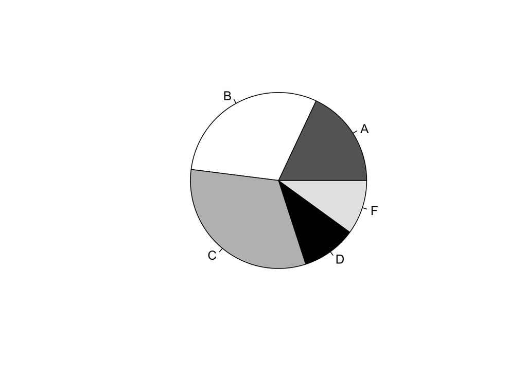

```r
groupsizes <- c(18, 30, 32, 10, 10)
labels <- c("A", "B", "C", "D", "F")
pie(groupsizes, labels, col=c("grey40", "white", "grey", "black", "grey90"))
```

### Histograms

類似Bar charts，不過用於**連續資料**的次數分佈呈現，這裡以內建資料集 `iris` 作為範例

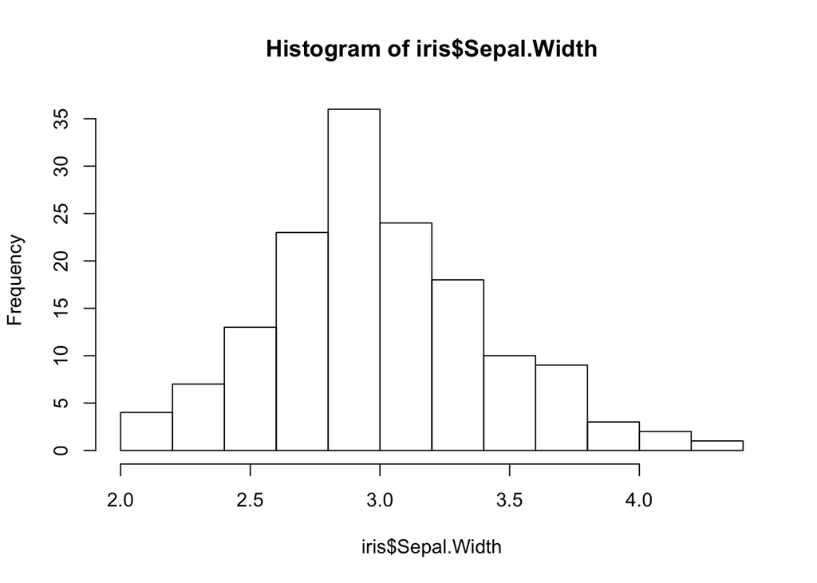

```r
hist(iris$Sepal.Width)
```

### Box plots

利用盒形圖可讓人一目了然資料的四分位數以及最大最小值

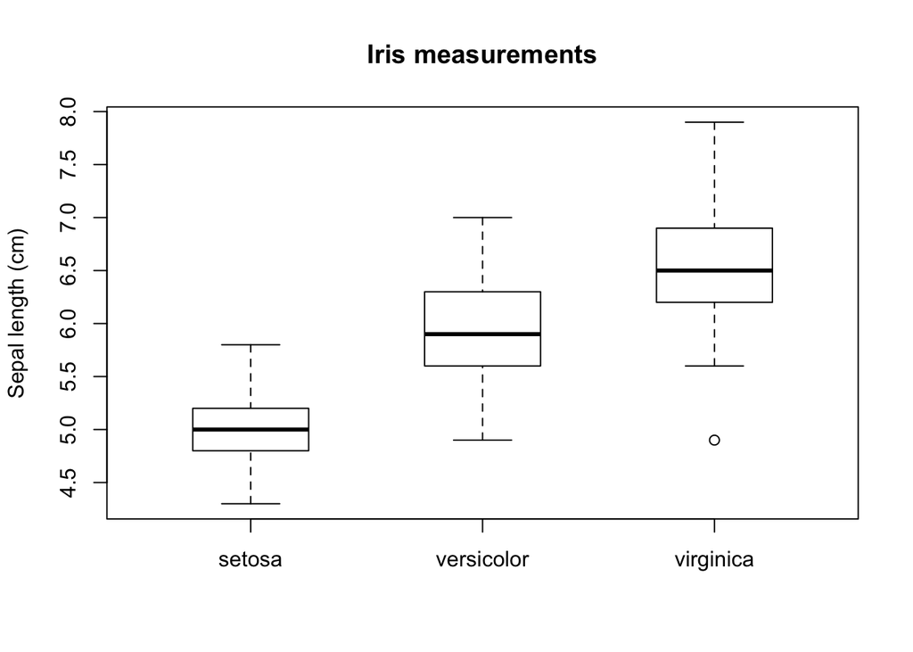

```r
boxplot(Sepal.Length  ~ Species, data = iris,
        ylab = "Sepal length (cm)", main = "Iris measurements",
        boxwex = 0.5)
```

### Scatterplots

用於觀察資料中兩個變數之間的關係，這裡以內建資料集 `mtcars` 作為範例

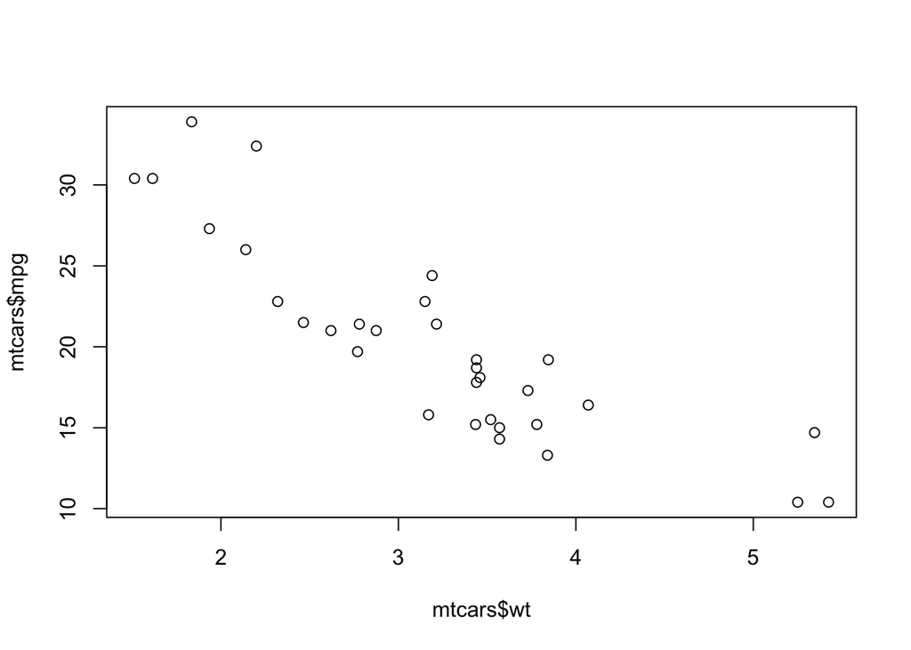

```r
plot(mtcars$wt, mtcars$mpg)
```

### QQ plots

分位數圖，用來檢驗樣本是否來自常態分佈的母體，是則其Q-Q 圖近似於一條直線，反之則否

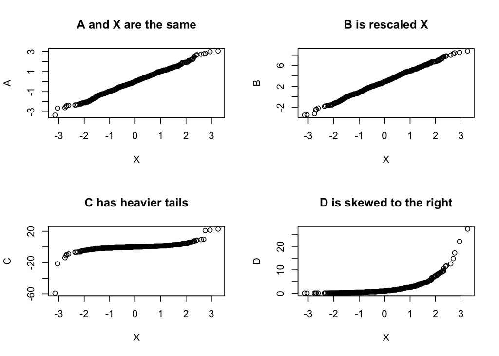

```r
par(mfrow = c(2,2)) # c(2,2)，表示建立一個2x2的空間，用來呈現多張圖
X <- rnorm(1000)
A <- rnorm(1000)
qqplot(X, A, main="A and X are the same")
B <- rnorm(1000, mean=3, sd=2)
qqplot(X, B, main="B is rescaled X")
C <- rt(1000, df=2)
qqplot(X, C, main="C has heavier tails")
D <- exp(rnorm(1000))
qqplot(X, D, main="D is skewed to the right")
```

### 3-2 Adding to plots

畫完基本的統計圖，可以透過一些函數在圖上加其他東西

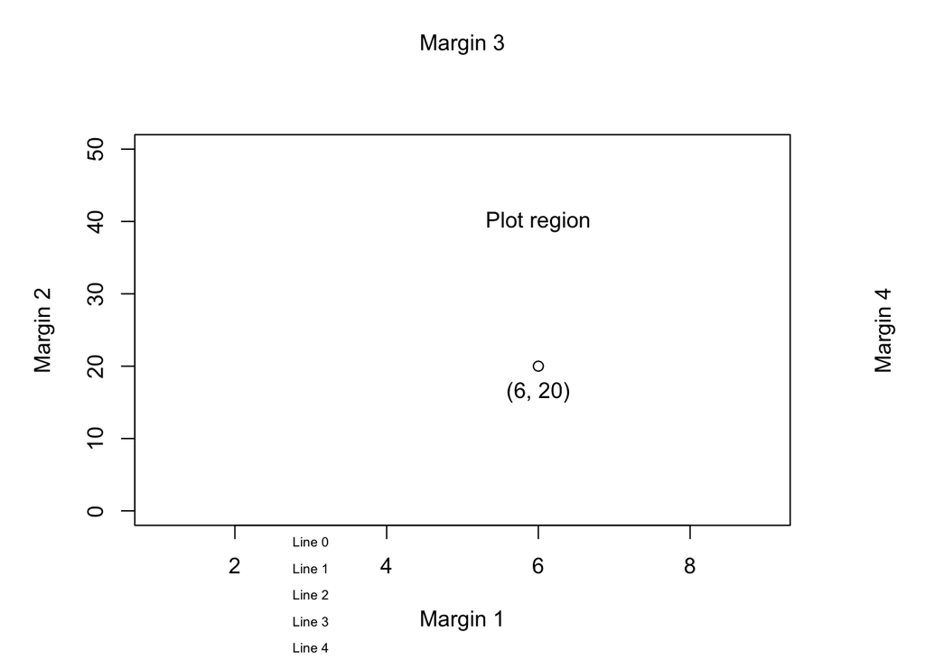

```r
par(mar=c(5, 5, 5, 5) + 0.1)  #設計一個四邊皆為5.1cm的繪圖空間
plot(c(1, 9), c(0, 50), type="n", xlab="", ylab="")
text(6, 40, "Plot region") #在（6,20) 加上文字
points(6, 20)  #標記點
text(6, 20, "(6, 20)", adj=c(0.5, 2))
mtext(paste("Margin", 1:4), side=1:4, line=3)  #在圖上加上文字
mtext(paste("Line", 0:4), side=1, line=0:4, at=3, cex=0.6)
```

## 4. Simulation

### 4-1 Uniform隨機數生成

利用`runif(n, min = a, max = b)`生成**均勻分布**的隨機數，其初始值為`a=0`,`b=1`

```r
runif(5)
```

```
## [1] 0.17158477 0.55940337 0.40585566 0.04521321 0.71361593
```

```r
runif(10, min = -3, max = -1)
```

```
##  [1] -2.429837 -1.518706 -2.646187 -1.656465 -2.913140 -1.315083 -2.481437
##  [8] -2.162988 -1.774149 -1.872164
```

### 4-2 其他分佈隨機數

#### Binomial random variables `rbinom(n, size, prob)`

```r
#The output from this function is the value of P(X = x)
dbinom(x = 4, size = 6, prob = 0.5)
```

```
## [1] 0.234375
```

```r
#Cumulative probabilities of the form P(X ≤ x)
 pbinom(4, 6, 0.5)
```

```
## [1] 0.890625
```

```r
#The 89th percentile of the distribution of X
qbinom(0.89, 6, 0.5)
```

```
## [1] 4
```

#### Poisson random variables `rpois(n, lambda)`

```r
#Calculate P(X = 3)
dpois(x = 3, lambda = 0.5)
```

```
## [1] 0.01263606
```

```r
#Cumulative probabilities of the form P(X ≤ x)：ppois()
# Poisson quantiles：qpois()
```

#### Exponential random numbers `rexp(n, rate)`

```r
rexp(10, rate = 3)
```

```
##  [1] 0.06497153 0.35183348 0.03182706 0.98168110 0.16667133 0.05993158
##  [7] 0.15214463 0.06133723 0.10478502 0.47785764
```

#### Normal random variables `rnorm(n, mean, sd)`

```r
rnorm(10, -3, 0.5)
```

```
##  [1] -2.486071 -2.717663 -3.735862 -2.546257 -2.602387 -2.733455 -3.148572
##  [8] -2.641428 -3.059816 -2.804892
```